# Simulating Poisson processes and compound Poisson processes

University of Toronto, ACT 350

Prof. S. Pesenti and K. Miao

03/10/2023

Learning goals: 1. simulation and intuition of Poisson processes, 2. simulation and intuition of compound Poisson processes, 3. introduction to rMarkdown, 4. introduction to tidyverse/dplyr, 5. introduction to ggplot.

# How to simulate a Poisson process

Recall that a Poisson process with rate $\lambda >0$ is a counting process $\{ N(t) : t \geq 0\}$ that has the following properties

1. *starts at 0*: $N(0) = 0$ with probability 1
2. *has independent increments*
3. *is increasing*: $N(s) \leq N(t)$ for all $s \leq t$
4. *has Poisson distributed increments*: $P(N(s + t) - N(s) = n) \sim$ Pois($\lambda t$) for all $s,t \geq 0$.

However, this definition does not help if we want to simulate a Poisson process. Thus, to simulate a Poisson process we use its alternative definition. That is, for independent random variables $X_1, X_2, \ldots$ that are Exponentially distributed with rate $\lambda>0$, a Poisson process with rate $\lambda>0$ can be written as

$$\begin{equation*}
N(t) = \max\Big\{ n \in \mathbb{N} ~\Big|~ \sum_{i = 1}^n X_i \leq t \Big\}, \quad \text{for all } t \geq 0.
\end{equation*}$$

Thus, for simulating a Poisson process we first need to simulate exponential random variables, add them up and check whether they are smaller or equal to $t$. However, we will run into problems when we want to store the value of $N(t)$ for every $0 \leq t < \infty$. The way out is to implement $N(t)$ as a function of $t$ in the following way. First generate the jump points of the Poisson process. Second, we know that a Poisson process can only jump one unit at a time. Thus, we can define the Poisson process as a step function that jumps exactly one unit at every jump point.

## 1. Generating jump times

This is an algorithm for generating the jump times of a Poisson process

1. Set $\tau_0 = 0$.
2. For $k \geq 1$ do
   1. generate $X \sim$Exp($\lambda$)
   2. set $\tau_k = \tau_{k - 1} + X$

The $\tau_k, ~ k = 0, 1, \ldots$ are the time points, where the Poisson process jumps.

**Numerical implementation: R code**

We demonstrate how to generate sample jump times in two ways:

```r
# set the seed for generating random variables (for reproducibility)
set.seed(0310)

# set the rate of the Poisson process/Exponential distribution
lambda <- 2

# number of jumps
n <- 50

# initialize the jump times
# let's do in matrix - we will change to tibble/dataframe later
jumps <- matrix(ncol = 3, nrow = n)

head(jumps)
```

```
##      [,1] [,2] [,3]
## [1,]   NA   NA   NA
## [2,]   NA   NA   NA
## [3,]   NA   NA   NA
## [4,]   NA   NA   NA
## [5,]   NA   NA   NA
## [6,]   NA   NA   NA
```

```r
# we have do step 1., setting $\tau_0 = 0$
jumps[1,] = c(1,0,1)

# now we can generate the rest of the sample
for(i in 2:n){
  jumps[i, 2] <- jumps[i - 1, 2] + rexp(1, lambda)
  jumps[i,3] = as.factor(1)
  jumps[i, 1] = i
}

head(jumps)
```

```
##      [,1]      [,2] [,3]
## [1,]    1 0.0000000    1
## [2,]    2 0.6936561    1
## [3,]    3 1.0369326    1
## [4,]    4 1.3594916    1
## [5,]    5 1.5650738    1
## [6,]    6 1.8360996    1
```

and

```r
# directly concatenate to our previous simulation
jumps = rbind(cbind(c(1:n), c(0, cumsum(rexp(n-1, lambda))), rep(2,n)), jumps)

head(jumps)
```

```
##      [,1]     [,2] [,3]
## [1,]    1 0.000000    2
## [2,]    2 2.229272    2
## [3,]    3 2.994915    2
## [4,]    4 4.458804    2
## [5,]    5 5.044406    2
## [6,]    6 5.565207    2
```

Which one is more efficient? Why?

We can easily add more sample jumps:

```r
jumps = rbind(cbind(c(1:n), c(0, cumsum(rexp(n-1, lambda))), rep(3,n)), jumps)

jumps = rbind(cbind(c(1:n), c(0, cumsum(rexp(n-1, lambda))), rep(4,n)), jumps)

head(jumps)
```

```
##      [,1]      [,2] [,3]
## [1,]    1 0.0000000    4
## [2,]    2 0.1073899    4
## [3,]    3 0.3720459    4
## [4,]    4 2.6008797    4
## [5,]    5 2.6462263    4
## [6,]    6 2.7696518    4
```

```r
jumps = data.frame(jumps)

# name the columns
colnames(jumps) = c("index", "sim", "path")

# you can also make sample in a wider matrix that would look like this
# how would you implement that?
jumps_w = pivot_wider(jumps, names_from = path, values_from = sim)

head(jumps_w)
```

```
## # A tibble: 6 x 5
##   index   `4`    `3`   `2`   `1`
##   <dbl> <dbl>  <dbl> <dbl> <dbl>
## 1     1 0     0       0    0
## 2     2 0.107 0.0904  2.23 0.694
## 3     3 0.372 1.06    2.99 1.04
## 4     4 2.60  1.13    4.46 1.36
## 5     5 2.65  1.77    5.04 1.57
## 6     6 2.77  2.66    5.57 1.84
```

Now, let’s plot our sample jumps:

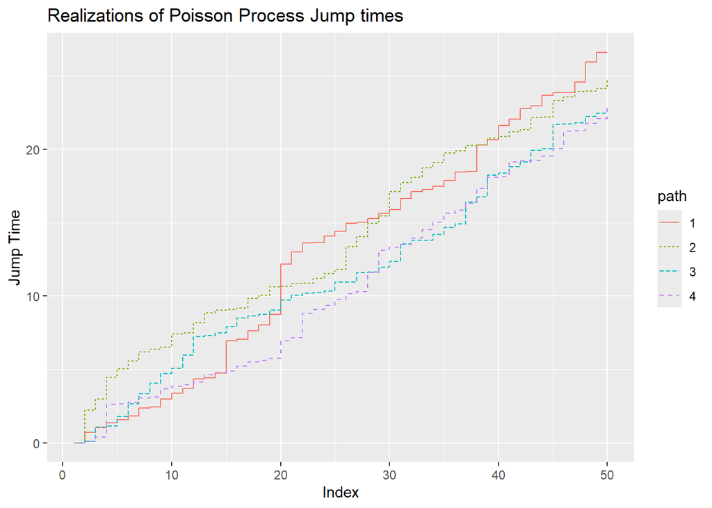

```r
# coerce our path label into factor type so we can use ggplot
jumps$path = as.factor(jumps$path)

# note that the four generated sample_paths are different,
# since the Exponential random variables are different samples.
ggplot(data = jumps, aes(x = index, y = sim)) +
  geom_step(aes(color = path, linetype = path)) +
  xlab("Index") + ylab("Jump Time") +
  ggtitle("Realizations of Poisson Process Jump times")
```

## 2. Defining the Poisson process as a function

Once the jump times have been simulated, we can go on to generate the Poisson process.

Next, we can define the Poisson process as a step function that jumps exactly one unit at every value in `jump_times`. Note that the implemented Poisson process is now a *function* of the time $t$.

```r
# need to massage the data some more, R complains about numeric names
names(jumps_w) = make.names(names(jumps_w))
# the default X# names are fine for our purposes

head(jumps_w)
```

```
## # A tibble: 6 x 5
##   index    X4     X3    X2    X1
##   <dbl> <dbl>  <dbl> <dbl> <dbl>
## 1     1 0     0       0    0
## 2     2 0.107 0.0904  2.23 0.694
## 3     3 0.372 1.06    2.99 1.04
## 4     4 2.60  1.13    4.46 1.36
## 5     5 2.65  1.77    5.04 1.57
## 6     6 2.77  2.66    5.57 1.84
```

```r
# define a Poisson process as a function taking inputs of jump times
# it outputs the value of a sample PP
poisson_process = function(jumpVector){
  stepfun(jumpVector[2 : n], seq(0, n - 1, by = 1))(0:n)
}

# the first argument of `stepfun` is where the step function jumps
# the second argument is the height of the step function

# Let us check some values.
# The starting value is 0.
poisson_process(jumpVector = jumps_w$X3)[1]
```

```
## [1] 0
```

```r
# What is the value of N(3)?
poisson_process(jumpVector = jumps_w$X3)[3]
```

```
## [1] 4
```

```r
poisson_process(jumpVector = jumps_w$X3)[10]
```

```
## [1] 17
```

```r
poisson_process(jumpVector = jumps_w$X3)[15]
```

```
## [1] 32
```

Note you can evaluate the Poisson process for any time point $t$, however, keep in mind that we only simulated 50 jumps of the Poisson process. Thus, evaluating $N(t)$ for large $t$ does not make sense.

## 3. Plotting a sample path

We have to apply our ‘poisson_process’ function to each of our sample paths. So let’s create a new dataframe that will contain this information.

```r
# apply the poisson process function to each of our sample jump times
PP = jumps_w %>%
  reframe(across(2:5, poisson_process)) %>%
  cbind(time = 0:n)

head(PP)
```

```
##   X4 X3 X2 X1 time
## 1  0  0  0  0    0
## 2  2  1  0  1    1
## 3  2  4  0  5    2
## 4  5  5  2  8    3
## 5 10  6  2 10    4
## 6 14  8  3 13    5
```

```r
# make a long version of the table with renaming (so we can use ggplot2)
PP_l = PP %>%
  pivot_longer(cols = 1:4) %>%
  rename(pPath = name, pVal = value)

head(PP_l)
```

```
## # A tibble: 6 x 3
##    time pPath  pVal
##   <int> <chr> <dbl>
## 1     0 X4        0
## 2     0 X3        0
## 3     0 X2        0
## 4     0 X1        0
## 5     1 X4        2
## 6     1 X3        1
```

To plot a sample path we have to plot the implemented step function `poisson_process`.

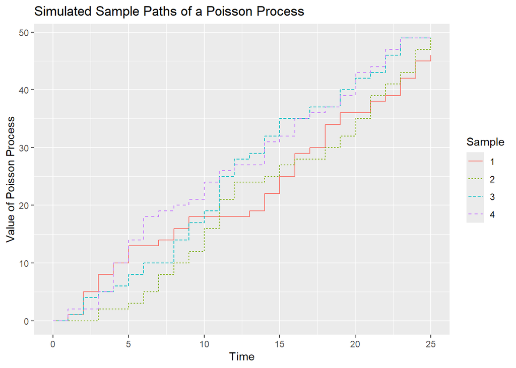

```r
ggplot(data = PP_l) +
  geom_step(aes(x = time, y = pVal, colour = pPath, linetype = pPath)) +
  xlim(c(0,25)) +
  xlab("Time") +
  ylab("Value of Poisson Process") +
  ggtitle("Simulated Sample Paths of a Poisson Process") +
  scale_colour_discrete(name  ="Sample",
                          breaks=c("X1", "X2", "X3", "X4"),
                          labels=c("1", "2", "3", "4")) +
  scale_linetype_discrete(name  ="Sample",
                          breaks=c("X1", "X2", "X3", "X4"),
                          labels=c("1", "2", "3", "4"))
```

```r
# what happens if I don't manually rename the legend?
```

## Confirming that samples are Poisson distributed

To (heuristically) check that our simulated process indeed follows a Poisson distribution, can do a few “eyeball tests”.

We have to generate samples from a Poisson process at a fixed time $t$.

```r
# set a fixed time
t = 8

# set a reasonable sample size
N = 1000

# intialize a vector to collect our samples at time t,
# and a vector to temporarily store jump times
tPois = rep(NA, N)
tempJumps = rep(NA, n)

# generate the samples
for (i in 1:N){
  tempJumps = c(0, cumsum(rexp(n-1, lambda)))
  # we overwrite this vector at every loop
  tPois[i] = poisson_process(jumpVector = tempJumps)[t + 1]
  # need to add 1 to account for index differences: R is 1 indexed
}
```

First, we can check the mean and variance.

```r
mean(tPois)
```

```
## [1] 15.934
```

```r
var(tPois)
```

```
## [1] 15.9516
```

This is consistent with the theory, noting that the variance and expectation of Poisson distributed random variables are equal. In a numerical setting, we can expect the values to get closer as the number of samples increases (recall: law of large numbers)

Also, recall for a Poisson process $\{N(t) : t \geq 0\}$:
$$\mathbb{E}[N(t)] = \lambda t = \text{Var}(N(t))$$
In particular, we have that $\lambda t = 2 \cdot 8 = 16$

Now we have the sample. What the next most obvious thing to look at if we want to confirm the distribution of a sample? Histogram!

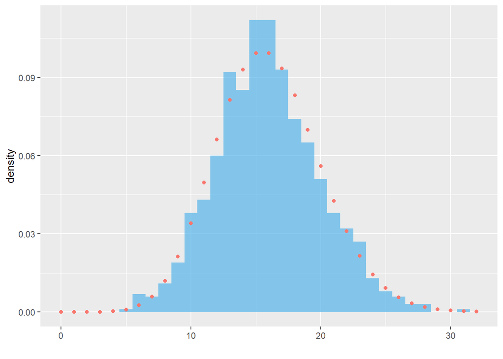

```r
ggplot() +
  geom_histogram(data = tibble(tPois),
                 aes(x = tPois, y = after_stat(density)),
                 binwidth = 1, fill = "#56B4E9", alpha = 0.7)  +
  geom_density() +
  stat_function(data = tibble(0:t*lambda*2),
                geom = "point", n = t*lambda*2 + 1, fun = dpois,
                args = list(lambda = t*lambda), aes(colour="#E69F00"),
                show.legend = FALSE) +
  xlim(c(0,t*lambda*2)) +
  xlab(" ")
```

The orange dots are the true values of a Poisson density. Why are they dots? Are you convince that our sample is Poisson distributed? Why or why not? How could we improve these results?

## Independent Increments

Let’s intuitively confirm that the increments are independent. Recall that for a Poisson Process $\{ N(t) : t \geq 0\}$, the increments $N(t+s) - N(s)$ is independent of $N(s)$. To test this numerically, I arbitrarily select $t = 4$ and $s = 3$ i.e. $t + s = 7$.

Let’s simulate a sample of $N(s) = N(3)$ and $N(t+s) = N(7)$.

```r
# set s
s = 3
r = 7 # denote r := t + s

#initialize our vectors
sPois = rep(NA, N)
rPois = rep(NA, N)

# generate the samples
for (i in 1:N){
  tempJumps = c(0, cumsum(rexp(n-1, lambda))) #using the same vec as before
  sPois[i] = poisson_process(jumpVector = tempJumps)[s + 1]
  rPois[i] = poisson_process(jumpVector = tempJumps)[r + 1]
}
```

How do we show independence between two samples? We can always eyeball a scatterplot.

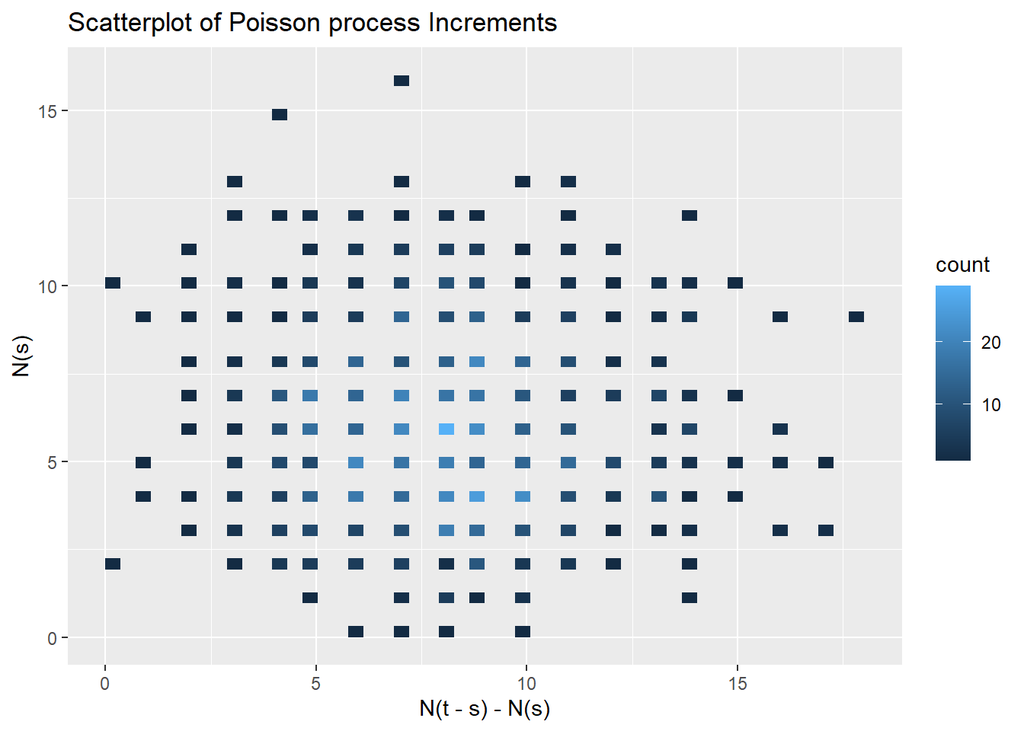

```r
ggplot() + geom_bin2d(aes(x = rPois - sPois, y = sPois), bins = 50) +
  xlab("N(t - s) - N(s)") +
  ylab("N(s)") +
  ggtitle("Scatterplot of Poisson process Increments")
```

Do you think these samples are independent based off of the scatter plot? Why or why not?

We can also check some independence tests… Consider the null hypothesis that our two samples are statistically independent. We perform a Pearson Chi-squared test (does our experiment satisfy the assumptions of this test?).

```r
chisq.test(x = rPois - sPois, y = sPois, correct = TRUE)
```

```
##
##  Pearson's Chi-squared test
##
## data:  rPois - sPois and sPois
## X-squared = 245.83, df = 270, p-value = 0.8518
```

We fail to reject the null hypothesis. This may or may not be convincing to you. Become confident in this fact by proving that Poisson increments are independent (HW).

# How to simulate a compound Poisson process

In order to construct a compound Poisson process, we need a (regular) Poisson process and a *jump size distribution*. Like Poisson processes, a compound Poisson process is also a jump process, meaning that it is a piecewise, increasing process. We define the compound Poisson process constructively:

Let $\{N(t) : t \geq 0\}$ be a Poisson process with rate $\lambda > 0$, let $F$ be a jump size distribution, and let random variables $X_i$, $i = 1, 2, \ldots$ follow the distribution $F$ identically and independently. Then, the compound Poisson distribution $\{W(t) : t \geq 0\}$ is defined as
$$W(t) := \sum_{i = 1}^{N(t)} X_i$$
for every $t \geq 0$.

We already know how to generate a Poisson process. Let’s make a new sample:

```r
# we can use the same sample sizes and parameters as earlier
# so we're not going to re-declare the variables

# generate the Poisson jumps
jumps_cPP = c(0, cumsum(rexp(n-1, lambda)))

# generate the Poisson Process
PP_cPP = poisson_process(jumpVector = jumps_cPP)
```

Now, we need to sample the jump sizes, sometimes this is called the *severity* of the compound Poisson process - especially in the context of actuarial science (recall the severity of insurance claims). We will consider the Weibull distribution with shape and parameters to be 0.75 and 1 respectively to be the severity. Note that the Weibull distribution with shape between 0 and 1 is a heavy tailed distribution.

```r
# generate samples from the jump size distribution
# let's use the Weibull(shape = 3/4, scale = 1)
shape = 3/4
scale = 1
severity = rweibull(500, shape, scale)
# we don't know how many jump size samples we'll need
# so I choose 500 to make sure we have enough
```

Now we have all the components necessary to generate one sample path of our compound Poisson process.

```r
# find the values of the compound Poisson process
value_cPP = c(0, cumsum(severity[1 : n - 1]))
```

And we plot this

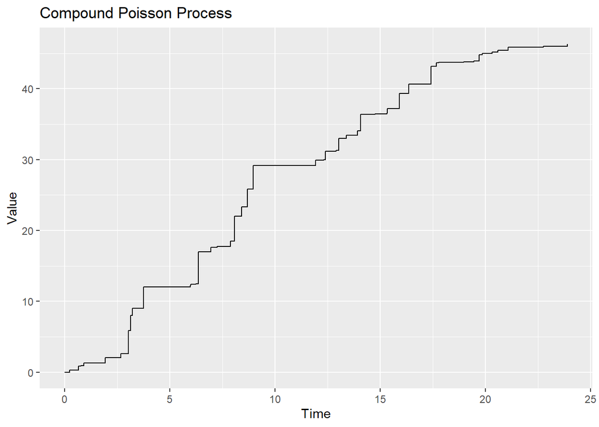

```r
ggplot() + geom_step(aes(x = jumps_cPP, y = value_cPP)) +
  xlab("Time") +
  ylab("Value") +
  ggtitle("Compound Poisson Process")
```

## Tasks:

1. Plot multiple sample paths of a compound Poisson Process in one plot and provide an interpretation.
2. Show that a compound Poisson process has the properties of a Poisson process, or provide a counterexample (in R and/or on paper), i.e. that it i) has value 0 at time 0, ii) is non-decreasing in time, iii) is Poisson distributed with rate $t \lambda$ at any time $t \geq 0$, and iv) that disjoint increments are independent.
3. An insurance company models a total claim portfolio via a compound Poisson process
   $$C(t) = \sum_{i = 1}^{N(t)} X_i$$
   where $C(t)$ is the total value of the claims at time $t$ (with weeks as unit), $X_1, X_2, \ldots$ are independently and identically distributed log-normally with a mean claim value of $1500 and standard deviation of $2000. The frequency of the claims is modelled by an (independent) Poisson process $\{N(t : t \geq 0)\}$ with an average of 4 claims per week.
   1. Implement this process in ‘R’ and plot 4 sample paths (in one plot) for a time period of at least 1 year. Discuss the results.
   2. What is the expected total claim to the insurance company after 6 months? What about 1 year? Solve on paper and approximate this in ’R”.
   3. Now, say that the intensity of the claims is not constant, i.e. consider $\lambda$ to be a function of time $t$. In particular, use $\lambda(t) = 3\left(\cos(\frac{t}{2\pi}) + 1\right)$. Why would an insurance company want to consider such a scenario? Repeat parts a) and b), and provide an interpretation.